# PSL (F20): Diabetes Data with Lasso

08/28/2020

## Diabetes Data

The Diabetes data (Efron et al, 2004) consists of ten baseline variables: `AGE`, `SEX`, `BMI` (body mass index), `BP` (average blood pressure), and six blood serum measurements `S1`, `S2`, `S3`, `S4`, `S5`, and `S6`, as well as the response of interest `Y`, a quantitative measure of disease progression one year after baseline, measured on n = 442 diabetes patients.

Data file `diabetes.data` can be found in dataset folder at the Resources page on Piazza.

```r
data = read.table("diabetes.data", header=TRUE)
dim(data)
```

```
[1] 442  11
```

## Lasso

```r
library(glmnet)
set.seed(1234)
X = data.matrix(data[, -11])
Y = data$Y
mylasso = glmnet(X, Y, alpha = 1)
```

You can call `mylasso$lambda` to check the lambda sequence used in the analysis, which is a monotonically decreasing sequence. The resulting model size (without counting the intercept) is stored in `mylasso$df`, which, however, is not necessarily a monotonically increasing sequence. Check the output below and notice how the model size goes from 10 to 9 and then back to 10.

```r
mylasso$df
```

```
 [1]  0  2  2  2  2  2  2  2  3  3  3  3  4  4  4  4  4  4  4  4  4
[22]  4  5  5  5  5  6  6  6  7  7  7  7  7  7  7  7  7  7  7  7  7
[43]  8  8  8  8  8  8  8  8  8  8  8  8  8  8  9 10 10 10 10 10 10
[64] 10 10 10 10  9  9  9  9  9  9 10 10 10 10 10 10 10 10 10 10 10
[85] 10 10 10 10
```

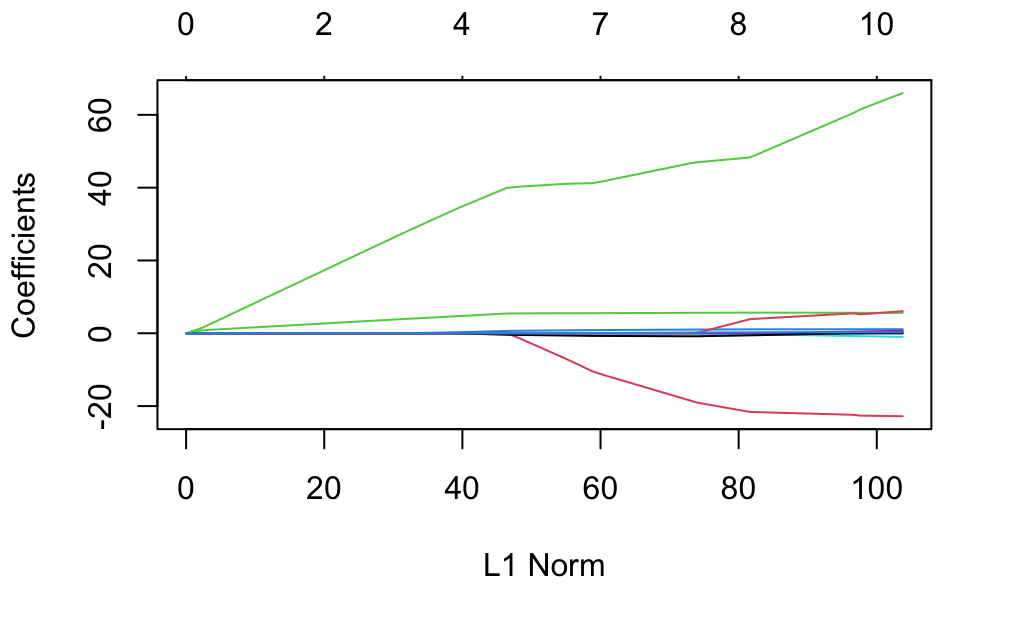

```r
plot(mylasso)
```

The pathplot above does not tell us much information. Next we display all Lasso coefficients (except the intercept) along the path of decreasing lambda values as an image, where a zero-coefficient is displayed as blank. Now you can see the coefficient of a variable changes from non-zero to zero and then back to non-zero when lambda decreases.

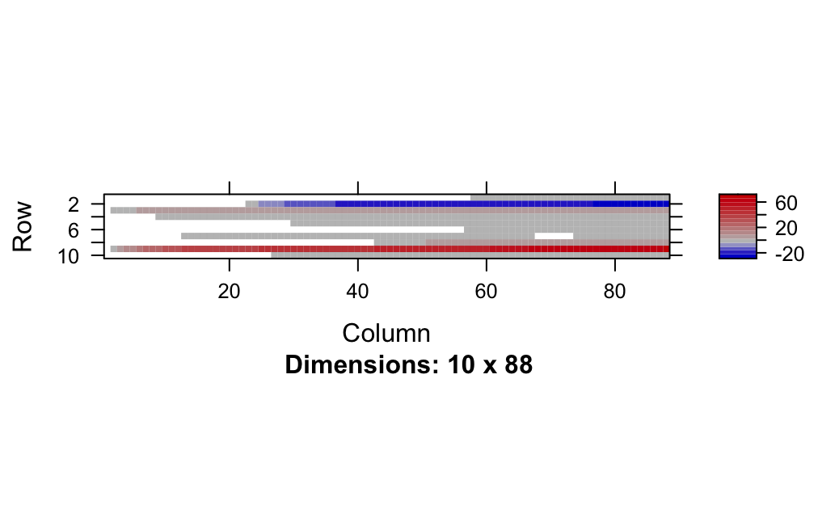

```r
lasso.coef = as.matrix(coef(mylasso))[-1, ]
image(coef(mylasso)[-1,])
```

You can print out `lasso.varset`, a 11-by-88 matrix that records selected variable over 88 different values of lamnda (denoted by s0, s1, …, s87).

```r
lasso.coef = as.matrix(coef(mylasso))
lasso.varset = ifelse(lasso.coef==0, 0, 1)
lasso.varset
```

Here is a summary of selected models on the path of Lasso:

- s0: intercept only (size = 0)
- s1: (BMI, S5) enters (size = 2)
- s8: BP enters (size = 3)
- s12: S3 enters (size = 4)
- s22: SEX enters (size = 5)
- s26: S6 enters (size = 6)
- s29: S1 enters (size = 7)
- s42: S4 enters (size = 8)
- s56: S2 enters (size = 9)
- s57: AGE enters (size = 10)
- s67: S3 leaves (size = 9)
- s73: S3 re-enters (size = 10)

S3 is an interesting variable. On the Lasso path, S3 got selected pretty early, appearing in a size four model (four non-intercept predictors); it stays non-zero for a long time but drops out briefly and then re-enters at the end.

## AIC/BIC

```r
library(leaps)
RSSleaps = regsubsets(X, Y, nbest=1, nvmax=10)
sumleaps = summary(RSSleaps, matrix=T)
sumleaps
```

```
Subset selection object
10 Variables  (and intercept)
    Forced in Forced out
AGE     FALSE      FALSE
SEX     FALSE      FALSE
BMI     FALSE      FALSE
BP      FALSE      FALSE
S1      FALSE      FALSE
S2      FALSE      FALSE
S3      FALSE      FALSE
S4      FALSE      FALSE
S5      FALSE      FALSE
S6      FALSE      FALSE
1 subsets of each size up to 10
Selection Algorithm: exhaustive
          AGE SEX BMI BP  S1  S2  S3  S4  S5  S6
1  ( 1 )  " " " " "*" " " " " " " " " " " " " " "
2  ( 1 )  " " " " "*" " " " " " " " " " " "*" " "
3  ( 1 )  " " " " "*" "*" " " " " " " " " "*" " "
4  ( 1 )  " " " " "*" "*" "*" " " " " " " "*" " "
5  ( 1 )  " " "*" "*" "*" " " " " "*" " " "*" " "
6  ( 1 )  " " "*" "*" "*" "*" "*" " " " " "*" " "
7  ( 1 )  " " "*" "*" "*" "*" "*" " " "*" "*" " "
8  ( 1 )  " " "*" "*" "*" "*" "*" " " "*" "*" "*"
9  ( 1 )  " " "*" "*" "*" "*" "*" "*" "*" "*" "*"
10  ( 1 ) "*" "*" "*" "*" "*" "*" "*" "*" "*" "*"
```

It is interesting to notice that none of the optimal size 4, 6, 7, 8 models from regsubsets contains has S3. It means if AIC/BIC ends up picking a model with size 4, 6, 7, or 8, then the AIC/BIC optimal model is not even on the path of Lasso.

You can check which model returned by AIC/BIC. Indeed the optimal model returned by AIC is of size 6, which does not include S3, but the optimal model returned by BIC is of size 5, which does include S3.

```r
n = length(Y)
msize=apply(sumleaps$which, 1, sum);
BIC = sumleaps$bic; BIC = BIC - min(BIC); BIC = BIC/max(BIC);
AIC = n*log(sumleaps$rss/n) + 2*msize;
AIC = AIC - min(AIC); AIC = AIC/max(AIC);
cbind(AIC, BIC)
```

```
           AIC         BIC
1  1.000000000 1.000000000
2  0.322396838 0.230742097
3  0.199478409 0.123584530
4  0.132534927 0.083241551
5  0.029652507 0.000000000
6  0.000000000 0.004169454
7  0.005806613 0.050664745
8  0.013262202 0.099128337
9  0.027634213 0.155847729
10 0.043603930 0.214474226
```